# Zadaća 1

Studenti:

```
Vedad Beglerović, Vildana Beglerović, Lejla Buturović
```

Nastavna grupa:

```
Grupa 1
```

## Zadatak 1 (Istraživanje podataka)

Upoznati se sa setom podataka i analizirati sve njegove karakteristike koristeći:  
- osnovne metode deskriptivne statistike, kao i:  
- metode procjene lokacije i varijabilnosti podataka;  
- metode za procjenu korelacije između varijabli.

Na osnovu izvršene analize potrebno je preprocesirati podatke za primjenu drveta odlučivanja (pročitati i povezati sa zadatkom 2).

Preprocesiranje podataka treba između ostalog da uključi:  
- popunjavanje svih nedostajućih vrijednosti;  
- odbacivanje svih pronađenih outliera;  
- odbacivanje atributa sa visokim stepenom korelacije;  
- vršenje transformacija podataka.

Sve izvršene korake potrebno je detaljno dokumentovati i objasniti razloge za primjenu odabranih metoda za sve atribute seta podataka. Obavezno koristiti ggplot2 napredne vizualizacijske funkcije za neke od grafika, na način kako je to urađeno u vježbi 2.

```r
podaci <- read.csv("customer_data_train.csv", fileEncoding = 'UTF-8')
```

Osnovne metode deskriprivne statistike:

```r
cat("Broj instanci: ", length(podaci$gender))
```

```
## Broj instanci:  2000
```

```r
cat("Broj atributa: ", length(podaci))
```

```
## Broj atributa:  14
```

```r
head(podaci)
```

```
##   gender Dependents tenure PhoneService    MultipleLines InternetService
## 1   Male         No      8          Yes               No            <NA>
## 2 Female       <NA>      8          Yes             <NA>     Fiber optic
## 3   <NA>         No     21          Yes               No     Fiber optic
## 4   <NA>       <NA>      1           No No phone service             DSL
## 5   <NA>         No     NA         <NA>             <NA>     Fiber optic
## 6   Male         No     69          Yes               No              No
##   StreamingTV StreamingMovies       Contract             PaymentMethod
## 1         Yes             Yes           <NA>                      <NA>
## 2          No              No Month-to-month   Credit card (automatic)
## 3         Yes             Yes       One year              Mailed check
## 4          No              No Month-to-month              Mailed check
## 5          No             Yes Month-to-month          Electronic check
## 6        <NA>            <NA>       Two year Bank transfer (automatic)
##   MonthlyCharges TotalCharges DailyCharges Churn
## 1             NA       832.35           NA   Yes
## 2             NA       548.90           NA    No
## 3         104.55      2239.40        20.91    No
## 4          35.90        35.90         7.18    No
## 5          81.10        81.10        16.22   Yes
## 6          19.30      1447.90         3.86    No
```

```r
cat("Kategorije spolova: ", unique(podaci$gender),
"\nKategorije izdrzavanja (dependents): ", unique(podaci$Dependents),
"\nKategorije PhoneServices: ", unique(podaci$PhoneService),
"\nKategorije (brojevi) nekretnina mušterije koji koriste usluge: ", sort(unique(podaci$tenure)),
"\nKategorije MulitpleLines: ", unique(podaci$MultipleLines),
"\nKategorije InternetService: ", unique(podaci$InternetService),
"\nKategorije StreamingTV: ", unique(podaci$StreamingTV),
"\nKategorije StreamingMovies: ", unique(podaci$StreamingMovies),
"\nKategorije ugovora: ", unique(podaci$Contract),
"\nKategorije metode plaćanja: ", unique(podaci$PaymentMethod),
"\nKategorije Churn: ", unique(podaci$Churn))
```

```
## Kategorije spolova:  Male Female NA
## Kategorije izdrzavanja (dependents):  No NA Yes Maybe
## Kategorije PhoneServices:  Yes No NA
## Kategorije (brojevi) nekretnina mušterije koji koriste usluge:  0 1 2 3 4 5 6 7 8 9 10 11 12 13 14 15 16 17 18 19 20 21 22 23 24 25 26 27 28 29 30 31 32 33 34 35 36 37 38 39 40 41 42 43 44 45 46 47 48 49 50 51 52 53 54 55 56 57 58 59 60 61 62 63 64 65 66 67 68 69 70 71 72
## Kategorije MulitpleLines:  No NA No phone service Yes
## Kategorije InternetService:  NA Fiber optic DSL No
## Kategorije StreamingTV:  Yes No NA No internet service
## Kategorije StreamingMovies:  Yes No NA No internet service
## Kategorije ugovora:  NA Month-to-month One year Two year
## Kategorije metode plaćanja:  NA Credit card (automatic) Mailed check Electronic check Bank transfer (automatic) abcd
## Kategorije Churn:  Yes No NA
```

```r
podaci_stari <-podaci
```

```r
#crtanje boxplotova za numeričke varijable
summary <- lapply(podaci, summary)
summary
```

```
## $gender
##    Length     Class      Mode
##      2000 character character
##
## $Dependents
##    Length     Class      Mode
##      2000 character character
##
## $tenure
##    Min. 1st Qu.  Median    Mean 3rd Qu.    Max.    NA's
##    0.00    9.00   29.00   32.52   56.00   72.00     247
##
## $PhoneService
##    Length     Class      Mode
##      2000 character character
##
## $MultipleLines
##    Length     Class      Mode
##      2000 character character
##
## $InternetService
##    Length     Class      Mode
##      2000 character character
##
## $StreamingTV
##    Length     Class      Mode
##      2000 character character
##
## $StreamingMovies
##    Length     Class      Mode
##      2000 character character
##
## $Contract
##    Length     Class      Mode
##      2000 character character
##
## $PaymentMethod
##    Length     Class      Mode
##      2000 character character
##
## $MonthlyCharges
##    Min. 1st Qu.  Median    Mean 3rd Qu.    Max.    NA's
##   -1.22   35.00   70.30   64.41   89.40  118.65     256
##
## $TotalCharges
##    Min. 1st Qu.  Median    Mean 3rd Qu.    Max.    NA's
##    19.1   433.4  1415.4  2280.6  3751.7 10000.0     276
##
## $DailyCharges
##    Min. 1st Qu.  Median    Mean 3rd Qu.    Max.    NA's
##  -0.244   6.940  14.050  12.855  17.880  23.730     255
##
## $Churn
##    Length     Class      Mode
##      2000 character character
```

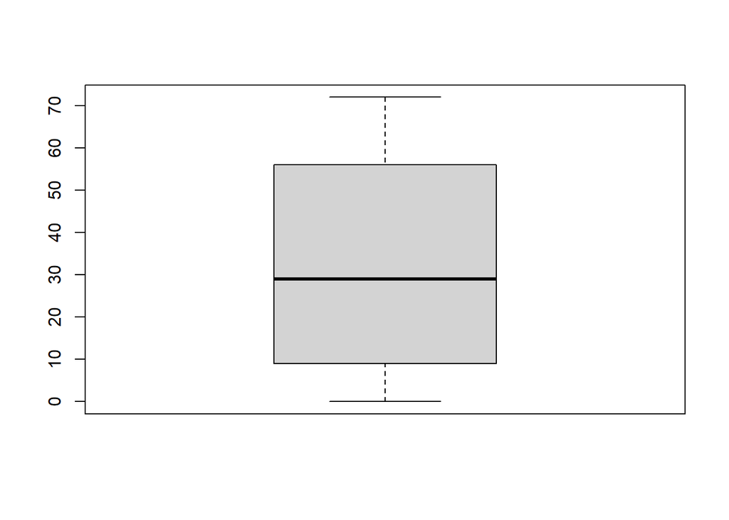

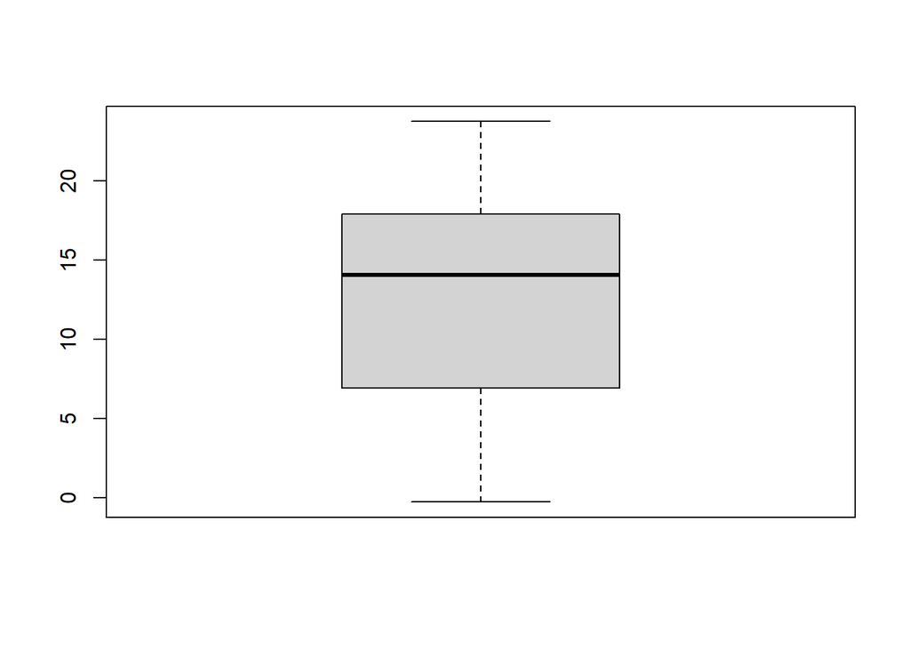

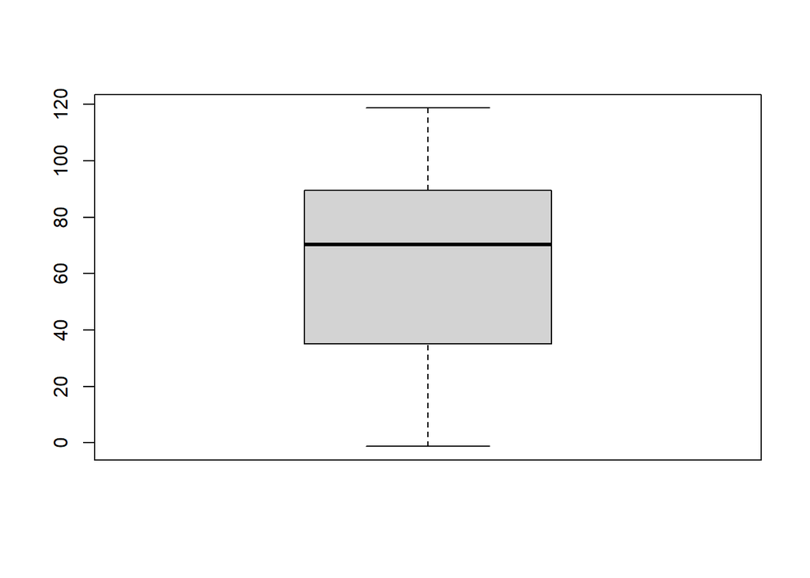

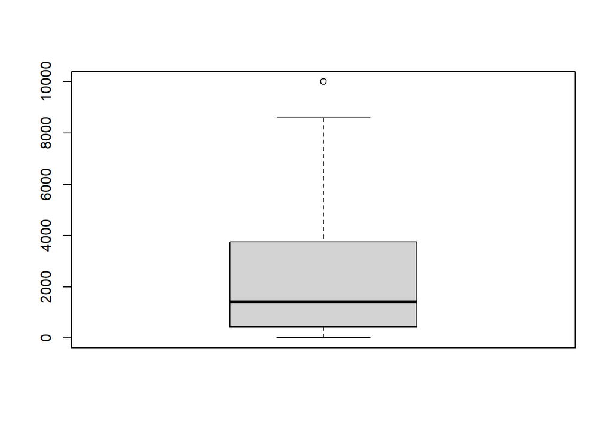

```r
num_cols <- subset(podaci, select = c(tenure, DailyCharges, MonthlyCharges, TotalCharges))
boxplots <- lapply(num_cols, boxplot)
```

```r
boxplots
```

```
## $tenure
## $tenure$stats
##      [,1]
## [1,]    0
## [2,]    9
## [3,]   29
## [4,]   56
## [5,]   72
##
## $tenure$n
## [1] 1753
##
## $tenure$conf
##          [,1]
## [1,] 27.22637
## [2,] 30.77363
##
## $tenure$out
## numeric(0)
##
## $tenure$group
## numeric(0)
##
## $tenure$names
## [1] "1"
##
##
## $DailyCharges
## $DailyCharges$stats
##        [,1]
## [1,] -0.244
## [2,]  6.940
## [3,] 14.050
## [4,] 17.880
## [5,] 23.730
##
## $DailyCharges$n
## [1] 1745
##
## $DailyCharges$conf
```

[output cut: 51 more lines]

```
## [1] 1724
##
## $TotalCharges$conf
##          [,1]
## [1,] 1289.125
## [2,] 1541.725
##
## $TotalCharges$out
## [1] 10000
##
## $TotalCharges$group
## [1] 1
##
## $TotalCharges$names
## [1] "1"
```

[figure not shown]

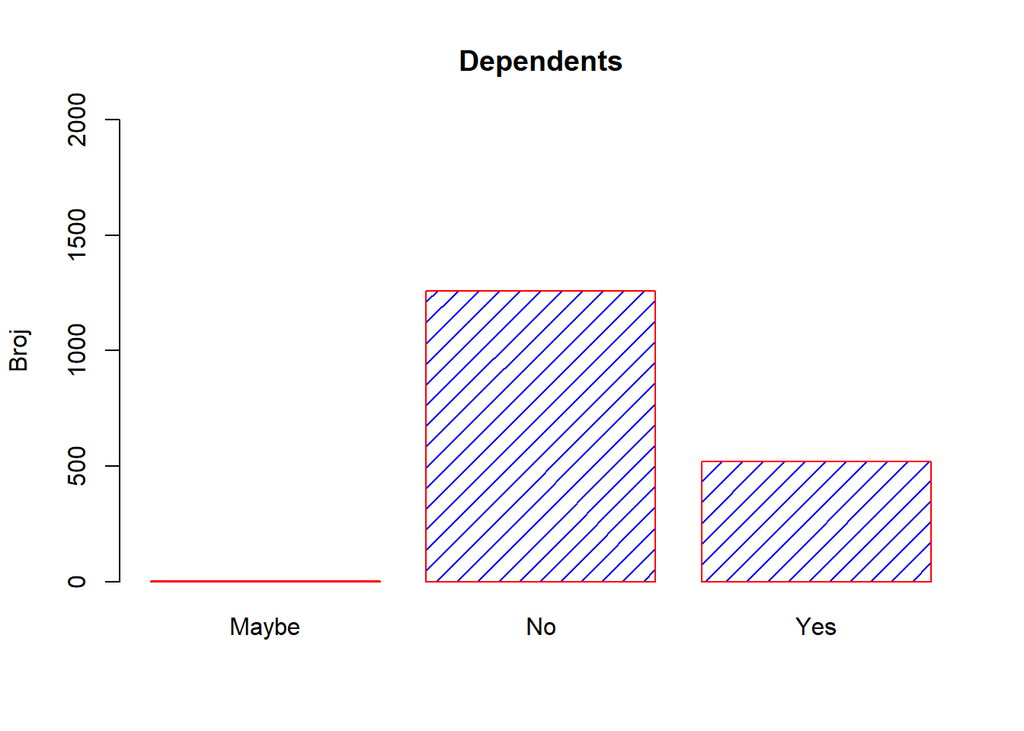

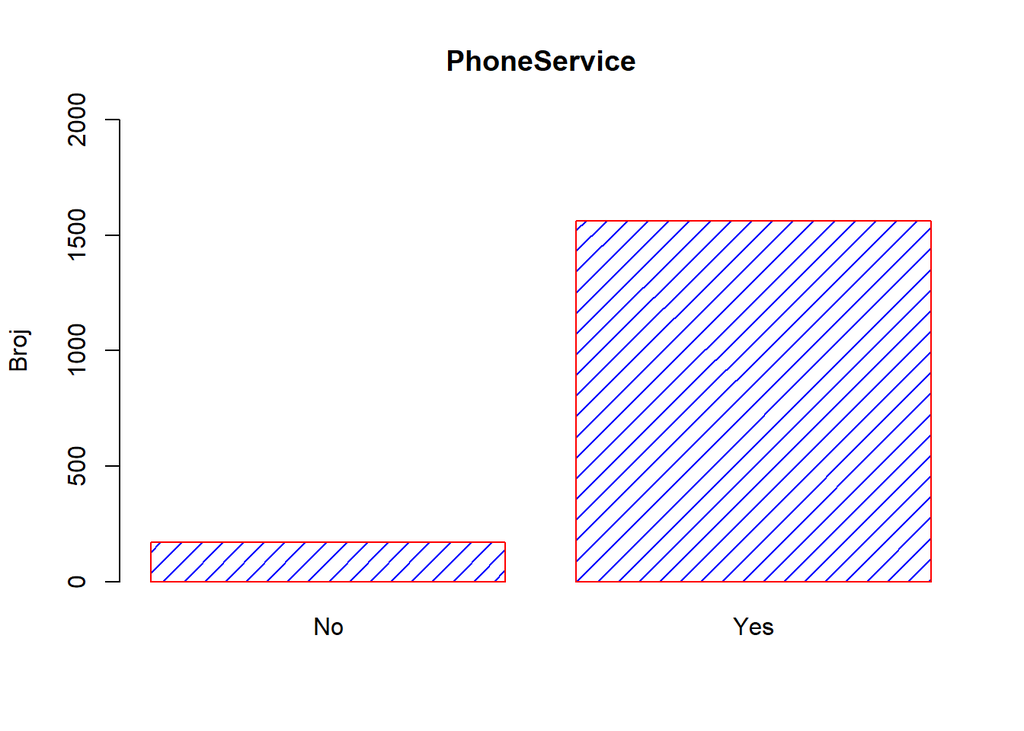

[figure not shown]

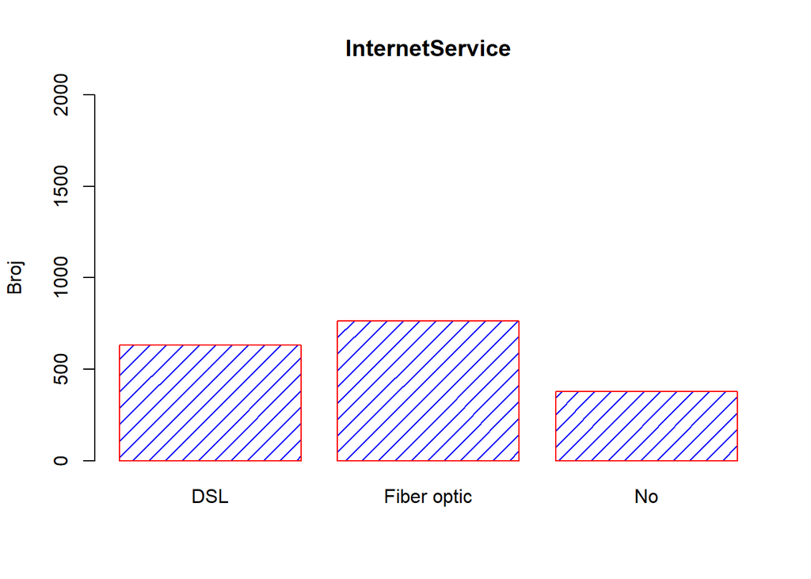

[figure not shown]

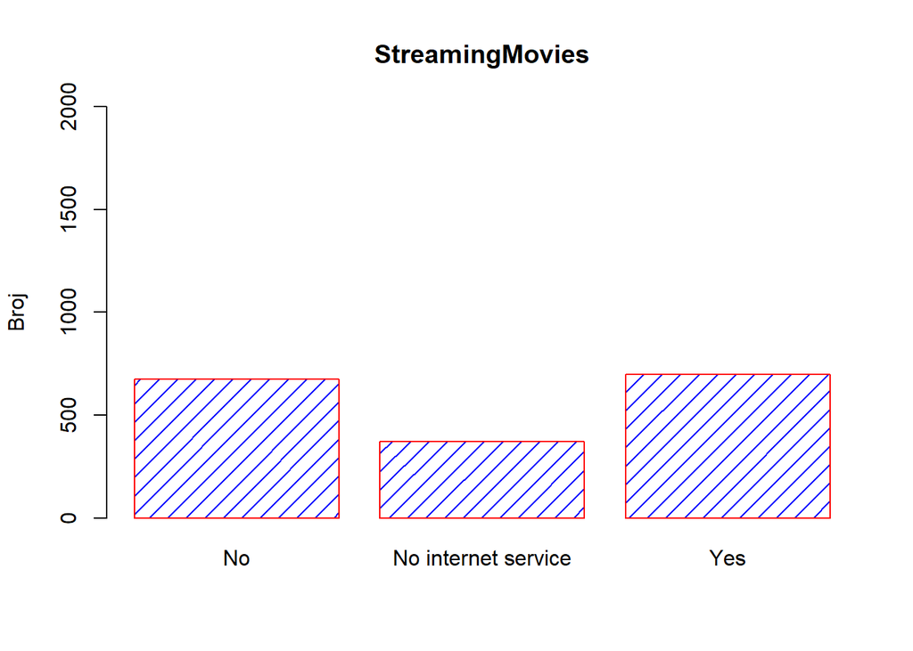

[figure not shown]

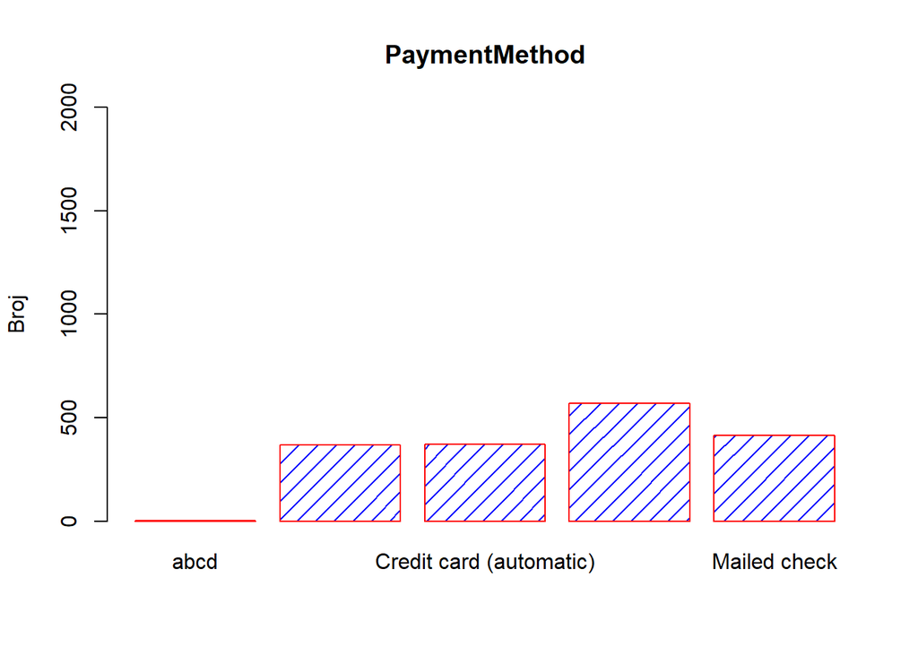

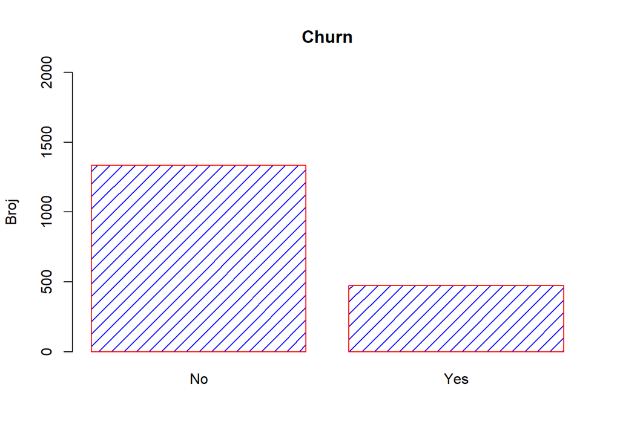

```r
for (i in colnames(podaci)){
  if (class(podaci[[i]]) == "character")
    barplot(table(podaci[[i]]),
    main=colnames(podaci[i]),
    ylim= c(0, length(podaci[[i]])),
    ylab="Broj",
    border="red",
    col="blue",
    density=10
    )
}
```

Analiza korelacije između numeričkih atributa - `tenure`, `DailyCharges`, `MonthlyCharges`, `TotalCharges` (Pearsonova korelacija):

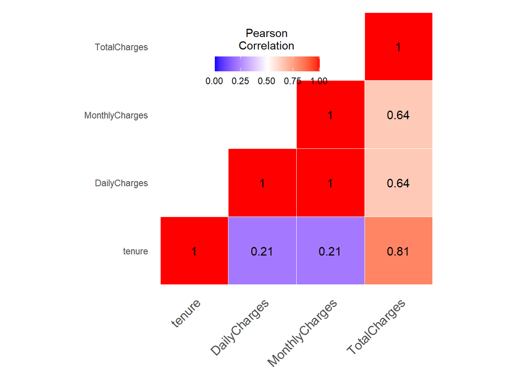

```r
library(reshape2)
library(ggplot2)
# funkcija za odsijecanje gornjeg dijela matrice
get_upper_tri <- function(cormat){
 cormat[lower.tri(cormat)]<- NA
 return(cormat)
}
# korelacijski koeficijent koristeći NA podatke ima rezultnu vrijednost NA
podaci_brojcani <- subset(podaci, select = c(tenure,DailyCharges,MonthlyCharges,TotalCharges))
podaci_brojcani_bez_na <- na.omit(podaci_brojcani)
# kreiranje korelacijske matrice za sve podatke
cormat <- round(cor(podaci_brojcani_bez_na), 2)
# odsijecanje gornjeg dijela matrice
upper_tri <- get_upper_tri(cormat)
melted_cormat <- melt(upper_tri, na.rm = TRUE)

ggheatmap <- ggplot(data = melted_cormat, aes(Var2, Var1, fill = value))+
geom_tile(color = "white")+
scale_fill_gradient2(low = "blue", high = "red", mid = "white",
 midpoint = 0.5, limit = c(0,1), space = "Lab",
 name="Pearson\nCorrelation") +
 theme_minimal()+
theme(axis.text.x = element_text(angle = 45, vjust = 1,
 size = 12, hjust = 1))+
coord_fixed()
ggheatmap +
geom_text(aes(Var2, Var1, label = value), color = "black", size = 4) +
theme(
 axis.title.x = element_blank(),
 axis.title.y = element_blank(),
 panel.grid.major = element_blank(),
 panel.border = element_blank(),
 panel.background = element_blank(),
 axis.ticks = element_blank(),
 legend.justification = c(1, 0),
 legend.position = c(0.6, 0.7),
 legend.direction = "horizontal")+
 guides(fill = guide_colorbar(barwidth = 7, barheight = 1,
 title.position = "top", title.hjust = 0.5))
```

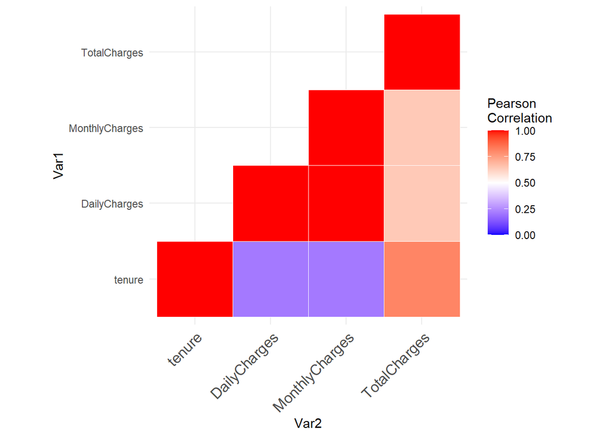

```r
 ggheatmap
```

```r
cat("Broj NA vrijednosti u koloni MonthlyCharges: ",length(subset(podaci, {is.na(podaci$MonthlyCharges)})$MonthlyCharges), "\nBroj NA vrijednosti u koloni DailyCharges: ",length(subset(podaci, {is.na(podaci$DailyCharges)})$DailyCharges))
```

```
## Broj NA vrijednosti u koloni MonthlyCharges:  256
## Broj NA vrijednosti u koloni DailyCharges:  255
```

```r
podaci <- subset(podaci, select = -c(DailyCharges))
head(podaci)
```

```
##   gender Dependents tenure PhoneService    MultipleLines InternetService
## 1   Male         No      8          Yes               No            <NA>
## 2 Female       <NA>      8          Yes             <NA>     Fiber optic
## 3   <NA>         No     21          Yes               No     Fiber optic
## 4   <NA>       <NA>      1           No No phone service             DSL
## 5   <NA>         No     NA         <NA>             <NA>     Fiber optic
## 6   Male         No     69          Yes               No              No
##   StreamingTV StreamingMovies       Contract             PaymentMethod
## 1         Yes             Yes           <NA>                      <NA>
## 2          No              No Month-to-month   Credit card (automatic)
## 3         Yes             Yes       One year              Mailed check
## 4          No              No Month-to-month              Mailed check
## 5          No             Yes Month-to-month          Electronic check
## 6        <NA>            <NA>       Two year Bank transfer (automatic)
##   MonthlyCharges TotalCharges Churn
## 1             NA       832.35   Yes
## 2             NA       548.90    No
## 3         104.55      2239.40    No
## 4          35.90        35.90    No
## 5          81.10        81.10   Yes
## 6          19.30      1447.90    No
```

```r
cat("Broj NA vrijednosti u koloni TotalCharges: ",length(subset(podaci, {is.na(podaci$TotalCharges)})$TotalCharges), "\nBroj NA vrijednosti u koloni tenure: ",length(subset(podaci, {is.na(podaci$tenre)})$tenure))
```

```
## Broj NA vrijednosti u koloni TotalCharges:  276
## Broj NA vrijednosti u koloni tenure:  0
```

```r
#podaci <- subset(podaci, select = -c(DailyCharges))
```

```r
library(tidyverse)
```

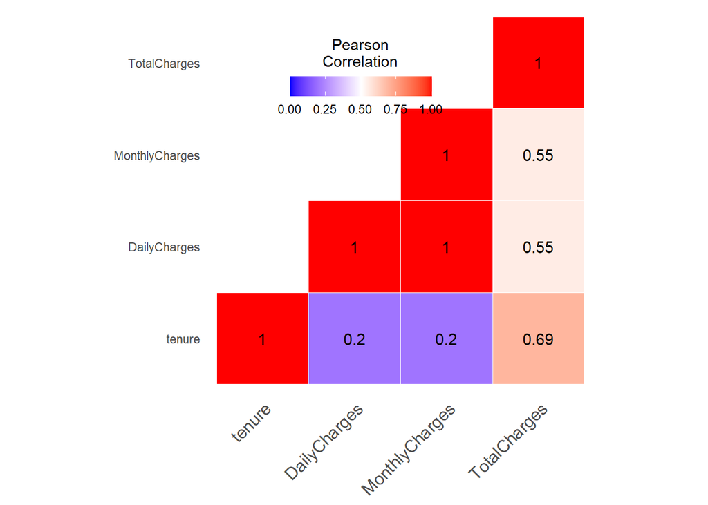

```r
podaci_brojcani <- podaci_brojcani %>%
mutate_if(is.numeric, function(x) ifelse(is.na(x), median(x, na.rm = T), x))
# funkcija za odsijecanje gornjeg dijela matrice
get_upper_tri <- function(cormat){
 cormat[lower.tri(cormat)]<- NA
 return(cormat)
}
# korelacijski koeficijent koristeći NA podatke ima rezultnu vrijednost NA
#podaci_brojcani <- subset(podaci, select = c(tenure,DailyCharges,MonthlyCharges,TotalCharges))
#podaci_brojcani_bez_na <- na.omit(podaci_brojcani)
# kreiranje korelacijske matrice za sve podatke
cormat <- round(cor(podaci_brojcani), 2)
# odsijecanje gornjeg dijela matrice
upper_tri <- get_upper_tri(cormat)
melted_cormat <- melt(upper_tri, na.rm = TRUE)

ggheatmap <- ggplot(data = melted_cormat, aes(Var2, Var1, fill = value))+
geom_tile(color = "white")+
scale_fill_gradient2(low = "blue", high = "red", mid = "white",
 midpoint = 0.5, limit = c(0,1), space = "Lab",
 name="Pearson\nCorrelation") +
 theme_minimal()+
theme(axis.text.x = element_text(angle = 45, vjust = 1,
 size = 12, hjust = 1))+
coord_fixed()
ggheatmap +
geom_text(aes(Var2, Var1, label = value), color = "black", size = 4) +
theme(
 axis.title.x = element_blank(),
 axis.title.y = element_blank(),
 panel.grid.major = element_blank(),
 panel.border = element_blank(),
 panel.background = element_blank(),
 axis.ticks = element_blank(),
 legend.justification = c(1, 0),
 legend.position = c(0.6, 0.7),
 legend.direction = "horizontal")+
 guides(fill = guide_colorbar(barwidth = 7, barheight = 1,
 title.position = "top", title.hjust = 0.5))
```

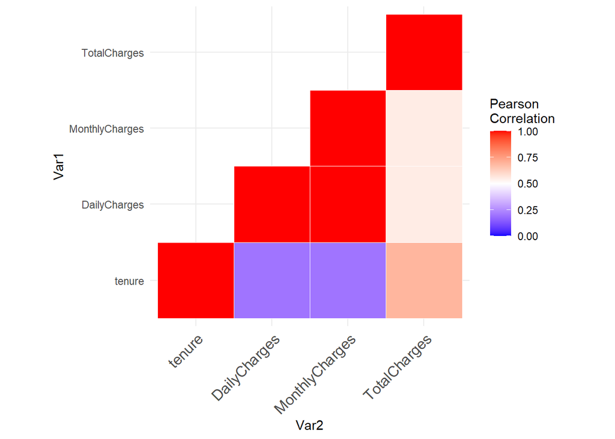

```r
 ggheatmap
```

```r
total_tenure <- subset(podaci, select = c(tenure,TotalCharges))
total_tenure_bez_na <- na.omit(total_tenure)
cor <- cor.test(total_tenure_bez_na$tenure, total_tenure_bez_na$TotalCharges, method = "pearson")
cat("Pearsonov koeficijent korelacije tenure-TotalCharges: ", cor$estimate)
```

```
## Pearsonov koeficijent korelacije tenure-TotalCharges:  0.8143779
```

Vidimo da se u navedenim kategorijama nalaze NA vrijednosti, što znači da imamo nedostajaćujih vrijednosti. U nastavku ćemo izvršiti analizu distribucije nedostajućih vrijednosti:

```r
#length(subset(podaci, {is.na(podaci$gender)})$MultipleLines)
#length(subset(podaci, is.na(podaci$MultipleLines)))
cat("Broj instanci dataseta: ", length(podaci$gender) , "\n",
    #ovdje fali DailyCharges u subsetu jer je u chunku iznad izbacena ta kolona
"Broj instanci sa NA vrijednostima u bilo kojoj koloni: ", length(subset(podaci, {is.na(gender) || is.na(Dependents) | is.na(tenure) | is.na(PhoneService) | is.na(MultipleLines) | is.na(InternetService) | is.na(StreamingTV) | is.na(StreamingMovies) | is.na(Contract) | is.na(PaymentMethod) | is.na(TotalCharges) | is.na(MonthlyCharges) | is.na(Churn)})$MultipleLines))
```

```
## Broj instanci dataseta:  2000
##  Broj instanci sa NA vrijednostima u bilo kojoj koloni:  1527
```

S obzirom da veliki broj instanci sadrži barem jednu nedostajuću vrijednost, neće biti adekvatno ignorisati te instance. Prvo je potrebno analizirati u kojim kolonama ima najviše nedefinisanih vrijednosti:

```r
library(VIM)
```

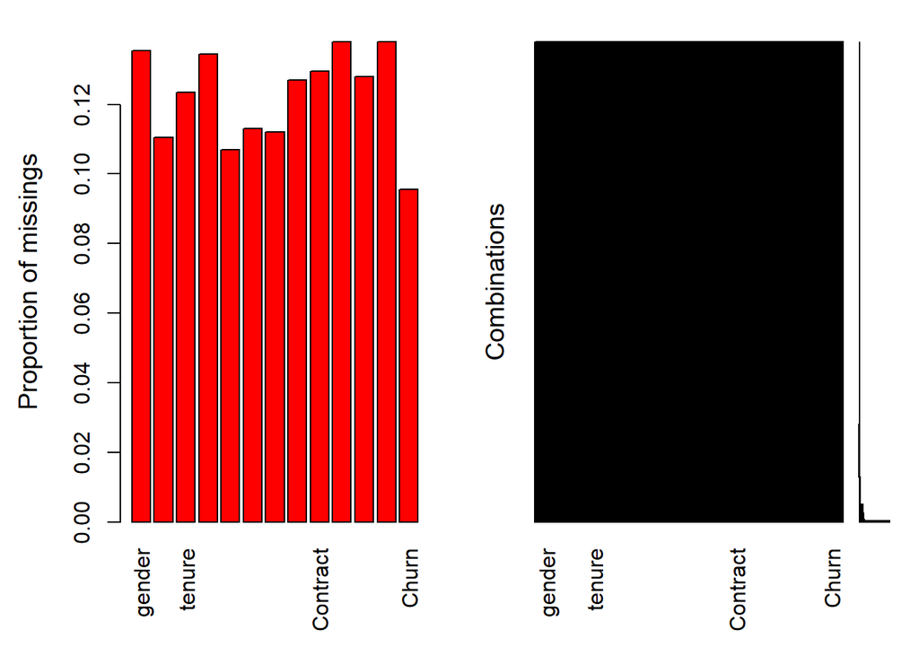

```r
aggr(podaci)
```

```r
podaci_stari <- podaci
```

popunjavanje nedostajućih vrijednosti svih brojčanih kolona (tenure, monthlyCharges, dailyCharges, TotalCharges)

```r
#popunjavanje nedostajućih vrijednosti svih brojcanih kolona (tenure, monthlyCharges, dailyCharges, TotalCharges)
#install.packages("tidyverse") https://www.codingprof.com/how-to-replace-missing-values-with-the-median-in-r/
library(tidyverse)
podaci <- podaci %>%
mutate_if(is.numeric, function(x) ifelse(is.na(x), median(x, na.rm = T), x))
```

*mean*, *trimmed_mean* i *median* vrijednosti za (brojcane) varijable `tenure`, `DailyCharges`, `MonthlyCharges`, `TotalCharges`. *Trimmed_mean* izračunati koristeći sljedeće vrijednosti parametra p: 1, 2 i 4:

```r
trimmed_mean <- function(vektor,p)
{
 vektor <- sort(vektor)
 trimmed_vektor <- vektor[(1 + p) : (length(vektor) - p)]
 return (sum(trimmed_vektor) / length(trimmed_vektor))
}

cat("Mean za broj nekretnina koje mušterija posjeduje:", mean(podaci_brojcani_bez_na$tenure),"\n")
```

```
## Mean za broj nekretnina koje mušterija posjeduje: 32.71132
```

```r
cat("Trimmed_mean za broj nekretnina koje mušterija posjeduje (p=1):", trimmed_mean(podaci_brojcani_bez_na$tenure, 1),"\n")
```

```
## Trimmed_mean za broj nekretnina koje mušterija posjeduje (p=1): 32.70547
```

```r
cat("Trimmed_mean za broj nekretnina koje mušterija posjeduje (p=2):", trimmed_mean(podaci_brojcani_bez_na$tenure, 2),"\n")
```

```
## Trimmed_mean za broj nekretnina koje mušterija posjeduje (p=2): 32.69961
```

```r
cat("Trimmed_mean za broj nekretnina koje mušterija posjeduje (p=4):", trimmed_mean(podaci_brojcani_bez_na$tenure, 4),"\n")
```

```
## Trimmed_mean za broj nekretnina koje mušterija posjeduje (p=4): 32.68784
```

```r
cat("Median za broj nekretnina koje mušterija posjeduje:", median(podaci$tenure), "\n\n")
```

```
## Median za broj nekretnina koje mušterija posjeduje: 29
```

```r
cat("Mean za dnevnu naplatu:", mean(podaci_brojcani_bez_na$DailyCharges),"\n")
```

```
## Mean za dnevnu naplatu: 12.79954
```

```r
cat("Trimmed_mean za dnevnu naplatu (p=1):", trimmed_mean(podaci_brojcani_bez_na$DailyCharges, 1),"\n")
```

```
## Trimmed_mean za dnevnu naplatu (p=1): 12.80116
```

```r
cat("Trimmed_mean za dnevnu naplatu (p=2):", trimmed_mean(podaci_brojcani_bez_na$DailyCharges, 2),"\n")
```

```
## Trimmed_mean za dnevnu naplatu (p=2): 12.80123
```

```r
cat("Trimmed_mean za dnevnu naplatu (p=4):", trimmed_mean(podaci_brojcani_bez_na$DailyCharges, 4),"\n")
```

```
## Trimmed_mean za dnevnu naplatu (p=4): 12.80168
```

```r
cat("Median za dnevnu naplatu:", median(podaci_brojcani_bez_na$DailyCharges), "\n\n")
```

```
## Median za dnevnu naplatu: 14
```

```r
 cat("Mean za mjesečnu naplatu:", mean(podaci$MonthlyCharges),"\n")
```

```
## Mean za mjesečnu naplatu: 65.16461
```

```r
 cat("Trimmed_mean za mjesečnu naplatu (p=1):", trimmed_mean(podaci$MonthlyCharges, 1),"\n")
```

```
## Trimmed_mean za mjesečnu naplatu (p=1): 65.17107
```

```r
 cat("Trimmed_mean za mjesečnu naplatu (p=2):", trimmed_mean(podaci$MonthlyCharges, 2),"\n")
```

```
## Trimmed_mean za mjesečnu naplatu (p=2): 65.16831
```

```r
 cat("Trimmed_mean za mjesečnu naplatu (p=4):", trimmed_mean(podaci$MonthlyCharges, 4),"\n")
```

```
## Trimmed_mean za mjesečnu naplatu (p=4): 65.16318
```

```r
 cat("Median za mjesečnu naplatu:", median(podaci$MonthlyCharges), "\n\n")
```

```
## Median za mjesečnu naplatu: 70.3
```

```r
head(podaci)
```

```
##   gender Dependents tenure PhoneService    MultipleLines InternetService
## 1   Male         No      8          Yes               No            <NA>
## 2 Female       <NA>      8          Yes             <NA>     Fiber optic
## 3   <NA>         No     21          Yes               No     Fiber optic
## 4   <NA>       <NA>      1           No No phone service             DSL
## 5   <NA>         No     29         <NA>             <NA>     Fiber optic
## 6   Male         No     69          Yes               No              No
##   StreamingTV StreamingMovies       Contract             PaymentMethod
## 1         Yes             Yes           <NA>                      <NA>
## 2          No              No Month-to-month   Credit card (automatic)
## 3         Yes             Yes       One year              Mailed check
## 4          No              No Month-to-month              Mailed check
## 5          No             Yes Month-to-month          Electronic check
## 6        <NA>            <NA>       Two year Bank transfer (automatic)
##   MonthlyCharges TotalCharges Churn
## 1          70.30       832.35   Yes
## 2          70.30       548.90    No
## 3         104.55      2239.40    No
## 4          35.90        35.90    No
## 5          81.10        81.10   Yes
## 6          19.30      1447.90    No
```

```r
summary <- lapply(podaci, summary)
summary
```

```
## $gender
##    Length     Class      Mode
##      2000 character character
##
## $Dependents
##    Length     Class      Mode
##      2000 character character
##
## $tenure
##    Min. 1st Qu.  Median    Mean 3rd Qu.    Max.
##    0.00   11.00   29.00   32.09   53.00   72.00
##
## $PhoneService
##    Length     Class      Mode
##      2000 character character
##
## $MultipleLines
##    Length     Class      Mode
##      2000 character character
##
## $InternetService
##    Length     Class      Mode
##      2000 character character
##
## $StreamingTV
##    Length     Class      Mode
##      2000 character character
##
## $StreamingMovies
##    Length     Class      Mode
##      2000 character character
##
## $Contract
##    Length     Class      Mode
##      2000 character character
##
## $PaymentMethod
##    Length     Class      Mode
##      2000 character character
##
## $MonthlyCharges
##    Min. 1st Qu.  Median    Mean 3rd Qu.    Max.
##   -1.22   44.80   70.30   65.16   85.80  118.65
##
## $TotalCharges
##    Min. 1st Qu.  Median    Mean 3rd Qu.    Max.
##    19.1   550.3  1415.4  2161.2  3237.0 10000.0
##
## $Churn
##    Length     Class      Mode
##      2000 character character
```

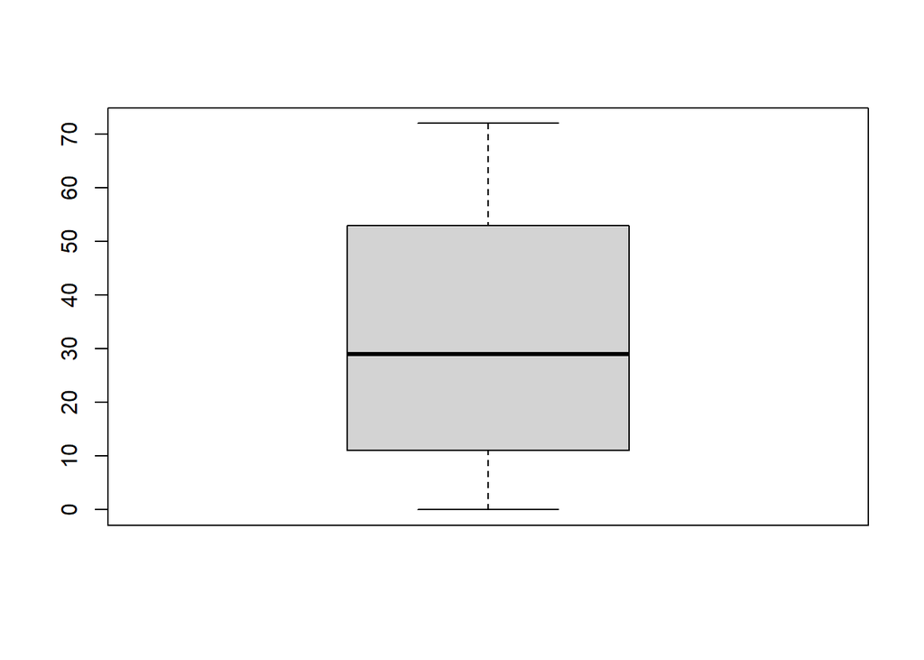

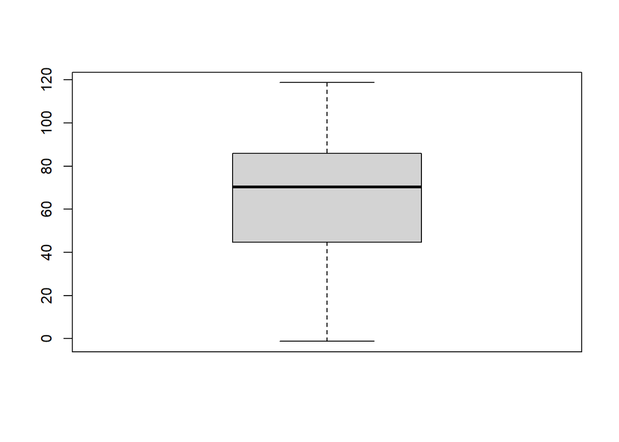

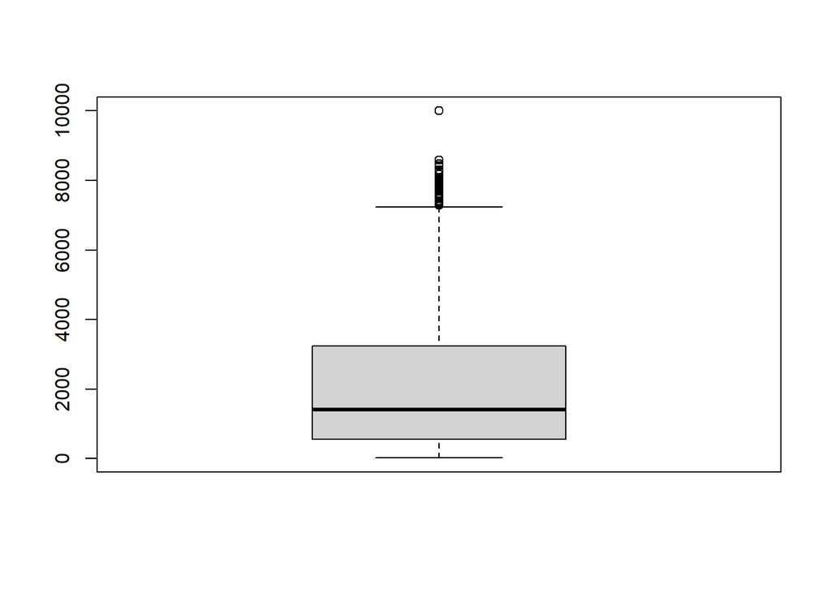

```r
num_cols <- subset(podaci, select = c(tenure, MonthlyCharges, TotalCharges))
boxplots <- lapply(num_cols, boxplot)
```

```r
boxplots
```

```
## $tenure
## $tenure$stats
##      [,1]
## [1,]    0
## [2,]   11
## [3,]   29
## [4,]   53
## [5,]   72
##
## $tenure$n
## [1] 2000
##
## $tenure$conf
##          [,1]
## [1,] 27.51615
## [2,] 30.48385
##
## $tenure$out
## numeric(0)
##
## $tenure$group
## numeric(0)
##
## $tenure$names
## [1] "1"
##
##
## $MonthlyCharges
## $MonthlyCharges$stats
##        [,1]
## [1,]  -1.22
## [2,]  44.80
## [3,]  70.30
## [4,]  85.80
## [5,] 118.65
##
## $MonthlyCharges$n
## [1] 2000
##
## $MonthlyCharges$conf
```

[output cut: 32 more lines]

```
##  [1]  8075.35  8425.15  7412.25  7383.70  8594.40 10000.00  7968.85  8289.20
##  [9]  7344.45  7576.70  7998.80  7711.25  7548.60  8477.60  7382.85  7288.40
## [17]  7548.10  7508.55  7982.50  7544.30  8424.90  7581.50  7397.00  7862.25
## [25]  7854.90  7379.80  8175.90  7318.20  7719.50  7690.90  8065.65  7878.30
## [33]  7806.60  7542.25  7795.95  7922.75  7789.60  8308.90  7521.95  7299.65
## [41]  7895.15  7559.55  7556.90  7616.00  7854.15  7544.00  7875.00  7470.10
## [49]  7679.65  7291.75  7323.15  7843.55  7348.80  7550.30  8405.00  7362.90
## [57]  8250.00  8476.50  7723.90
##
## $TotalCharges$group
##  [1] 1 1 1 1 1 1 1 1 1 1 1 1 1 1 1 1 1 1 1 1 1 1 1 1 1 1 1 1 1 1 1 1 1 1 1 1 1 1
## [39] 1 1 1 1 1 1 1 1 1 1 1 1 1 1 1 1 1 1 1 1 1
##
## $TotalCharges$names
## [1] "1"
```

Popunjavanje vrijednosti Na za kategoričke varijable:

```r
male<-0
dependent<-0
for (i in 1 : length(podaci$gender))
{
  # #popunjavanje NA vrijednosti za InternetService ako je u StreamingMOvies No internet service
  # if (is.na(podaci$InternetService[i]) == TRUE & is.na(podaci$StreamingMovies[i]) == FALSE & podaci$StreamingMovies[i]=="No internet service")
  # {
  #   podaci$InternetService[i] <- "No"
  # }
  #
  # #popunjavanje NA vrijednosti za InternetService ako je u StreamingTV No internet service
  # if (is.na(podaci$InternetService[i]) == TRUE & is.na(podaci$StreamingTV[i]) == FALSE & podaci$StreamingTV[i]=="No internet service")
  # {
  #   podaci$InternetService[i] <- "No"
  # }
  # #popunjavanje StreamingMovies na No internet service ako je InternetService No
  # if (is.na(podaci$StreamingMovies[i]) == TRUE & is.na(podaci$InternetService[i]) == FALSE & podaci$InternetService[i]=="No")
  # {
  #   podaci$StreamingMovies[i] <- "No internet service"
  # }
  #popunjavanje StreamingTV na No internet service ako je InternetService No
  if (is.na(podaci$StreamingTV[i]) == TRUE & is.na(podaci$InternetService[i]) == FALSE & podaci$InternetService[i]=="No")
  {
    podaci$StreamingTV[i] <- "No internet service"
  }
  #popunjavanje PhoneService na Yes ako je MultipleLines yes
  if (is.na(podaci$PhoneService[i]) == TRUE & is.na(podaci$MultipleLines[i]) == FALSE & podaci$MultipleLines[i]=="Yes")
  {
    podaci$PhoneService[i] <- "Yes"
  }
  # #popunjavanje MultipleLines na No phone service ako je Phone Service No
  # if (is.na(podaci$PhoneService[i]) == FALSE  & podaci$PhoneService[i]=="No" & is.na(podaci$MultipleLines[i]))
  # {
  #   podaci$MultipleLines[i] <- "No phone service"
  # }
  # #popunjavanje InternetService na DSL ako je Phone Service No
  # if (is.na(podaci$PhoneService[i]) == FALSE  & podaci$PhoneService[i]=="No" & is.na(podaci$InternetService[i]))
  # {
  #   podaci$InternetService[i] <- "DSL"
  # }
  # #popunjavanje MultipleLines na No phone service ako je Phone Service No
  # if (is.na(podaci$MultipleLines[i]) == FALSE  & podaci$MultipleLines[i]=="No phone service" & is.na(podaci$PhoneService[i]))
  # {
  #   podaci$PhoneService[i] <- "No"
  # }
   if (is.na(podaci$gender[i]) == TRUE)
  {
     if (male == 1){
      podaci$gender[i] <- "Female"
      male<-0
     } else {
        podaci$gender[i] <- "Male"
        male<-1
     }
   }
   if (is.na(podaci$Dependents[i]) == TRUE)
  {
     if (dependent == 1){
      podaci$Dependents[i] <- "No"
      dependent<-0
     } else {
        podaci$Dependents[i] <- "Yes"
        dependent<-1
     }
   }
  #ako su PhoneService i MultipleLines oba Na
  if (is.na(podaci$PhoneService[i]) == TRUE & is.na(podaci$MultipleLines[i])==TRUE){
    podaci$PhoneService[i]<-'No'
    podaci$MultipleLines[i]<-'No phone service'
  }
  #ako su InternetService i StreamingTV i StreamingMovies svi Na
  if (is.na(podaci$InternetService[i]) == TRUE & is.na(podaci$StreamingTV[i])==TRUE & is.na(podaci$StreamingMovies[i])==TRUE){
    podaci$InternetService[i]<-'No'
    podaci$StreamingTV[i]<-'No internet service'
    podaci$StreamingMovies[i]<-'No internet service'
  }
  #ako su InternetService i StreamingTV Na i StreamingMovies No
  if (is.na(podaci$InternetService[i]) == TRUE & is.na(podaci$StreamingTV[i])==TRUE & podaci$StreamingMovies[i]=='No'){
    podaci$InternetService[i]<-'No'
    podaci$StreamingTV[i]<-'No internet service'
  }
  #ako su InternetService i StreamingMovies Na i StreamingTV No
  if (is.na(podaci$InternetService[i]) == TRUE & is.na(podaci$StreamingMovies[i])==TRUE & podaci$StreamingTV[i]=='No'){
    podaci$InternetService[i]<-'No'
    podaci$StreamingMovies[i]<-'No internet service'
  }
  if (is.na(podaci$InternetService[i]) == TRUE){
    podaci$InternetService[i]<-'DSL'
  }
  if (is.na(podaci$PhoneService[i]) == TRUE){
    podaci$PhoneService[i]<-'Yes'
  }
  if (is.na(podaci$MultipleLines[i]) == TRUE){
    podaci$MultipleLines[i]<-'Yes'
  }
  if (is.na(podaci$StreamingTV[i]) == TRUE){
    podaci$StreamingTV[i]<-'Yes'
  }
   if (is.na(podaci$StreamingMovies[i]) == TRUE){
    podaci$StreamingMovies[i]<-'Yes'
   }
  if (is.na(podaci$Contract[i]) == TRUE){
    podaci$Contract[i]<-'Month-to-month'
  }
  if (is.na(podaci$PaymentMethod[i]) == TRUE){
    podaci$PaymentMethod[i]<-'Electronic check'
  }
}
```

```r
print(subset(podaci, Dependents == "Maybe"))
```

```
##     gender Dependents tenure PhoneService MultipleLines InternetService
## 550 Female      Maybe     61          Yes            No             DSL
##     StreamingTV StreamingMovies Contract             PaymentMethod
## 550          No              No One year Bank transfer (automatic)
##     MonthlyCharges TotalCharges Churn
## 550           49.7     1415.425    No
```

```r
print(subset(podaci, PaymentMethod == "abcd"))
```

```
##    gender Dependents tenure PhoneService MultipleLines InternetService
## 70   Male         No      1          Yes            No              No
##            StreamingTV StreamingMovies       Contract PaymentMethod
## 70 No internet service             Yes Month-to-month          abcd
##    MonthlyCharges TotalCharges Churn
## 70          19.45     1415.425    No
```

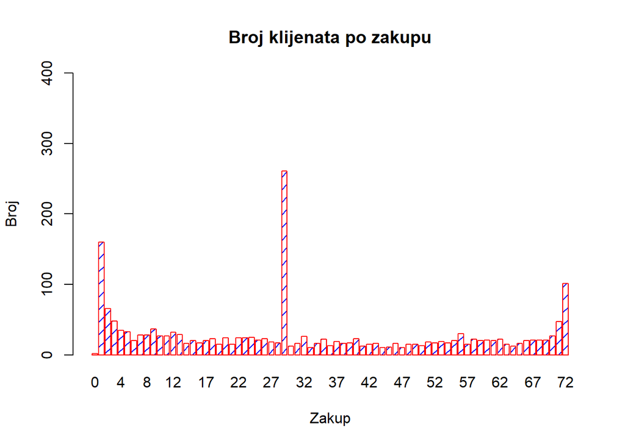

```r
barplot(table(podaci$tenure),
main="Broj klijenata po zakupu",
ylim= c(0, length(podaci$tenure)/5),
xlab="Zakup",
ylab="Broj",
border="red",
col="blue",
density=10
)
```

```r
print(subset(podaci, tenure == 0))
```

```
##      gender Dependents tenure PhoneService MultipleLines InternetService
## 76   Female        Yes      0          Yes           Yes             DSL
## 1632 Female        Yes      0          Yes            No             DSL
##      StreamingTV StreamingMovies       Contract PaymentMethod MonthlyCharges
## 76           Yes             Yes Month-to-month  Mailed check          73.35
## 1632         Yes             Yes       Two year  Mailed check          70.30
##      TotalCharges Churn
## 76       1415.425    No
## 1632     1415.425    No
```

```r
#izbacivanje outliera
podaci <- podaci[!rownames(podaci) %in% c("550", "70", "76","1632"), ]
```

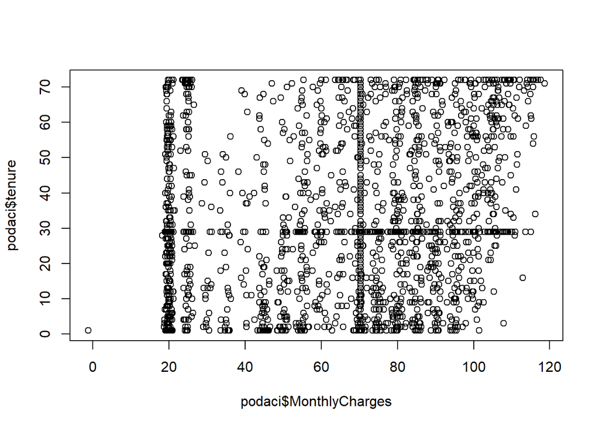

```r
#izbacivanje outliera numeričkih atributa

plot(podaci$MonthlyCharges, podaci$tenure)
```

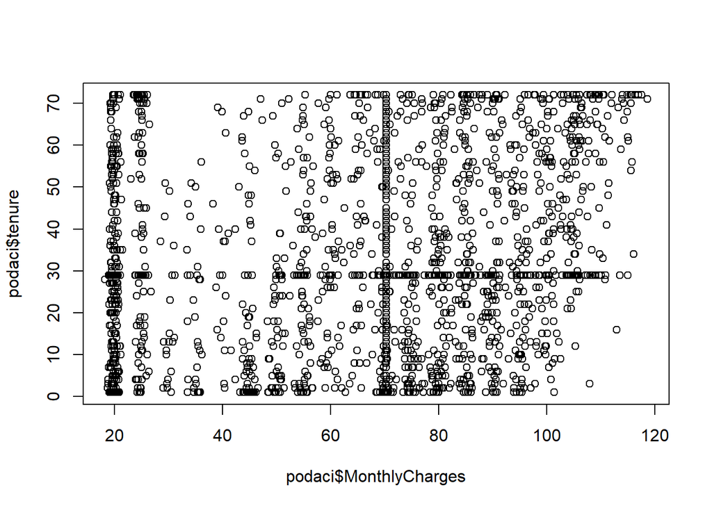

```r
#outlier
index_minimuma <- which.min(podaci$MonthlyCharges)
podaci <- subset(podaci, MonthlyCharges>0)
plot(podaci$MonthlyCharges, podaci$tenure)
```

```r
#korelacija kategoričkih varijabli
chi_matrica <- matrix(0,ncol(podaci), ncol(podaci))
rownames(chi_matrica) <- colnames(podaci)
colnames(chi_matrica) <- colnames(podaci)
critical_matrica <- matrix(0,ncol(podaci), ncol(podaci))
rownames(critical_matrica) <- colnames(podaci)
colnames(critical_matrica) <- colnames(podaci)
razlika_matrica <- matrix(0,ncol(podaci), ncol(podaci))
rownames(razlika_matrica) <- colnames(podaci)
colnames(razlika_matrica) <- colnames(podaci)
for (k in colnames(podaci)){
  atribut1 <- sort(unique(podaci[[k]]))
  for (l in colnames(podaci)){
    atribut2 <- sort(unique(podaci[[l]]))
   if(class(podaci[[k]]) == "character" & class(podaci[[l]]) == "character"){
        data2 <- matrix(0, length(atribut1), length(atribut2))
        rownames(data2) <- atribut1
        colnames(data2) <- atribut2
        cat("\nMatrica korelacije atributa ", colnames(podaci[k]), " i ", colnames(podaci[l]), ":\n\n")
            for (i in 1 : length(atribut1)) {

                for (j in 1 : length(atribut2)) {

                    redovi <- subset(podaci, (podaci[[k]] == atribut1[i] & podaci[[l]] == atribut2[j]))
                    data2[i, j] = length(redovi[[k]])
                }
            }
      print(data2)
      chi <- chisq.test(data2)
      chi_matrica[k,l] <- chi$statistic
      critical <- qchisq(p = chi$p.value, df = chi$parameter)
      critical_matrica[k,l] <- critical
      if(chi$statistic - critical >0){
      razlika_matrica[k,l] <- chi_matrica[k,l] - critical
      }
   }
  }
}
```

```
##
## Matrica korelacije atributa  gender  i  gender :
##
##        Female Male
## Female   1013    0
## Male        0  982
##
## Matrica korelacije atributa  gender  i  Dependents :
##
##         No Yes
## Female 686 327
## Male   681 301
##
## Matrica korelacije atributa  gender  i  PhoneService :
##
##         No Yes
## Female 101 912
## Male    99 883
##
## Matrica korelacije atributa  gender  i  MultipleLines :
##
##         No No phone service Yes
## Female 437              112 464
## Male   425              104 453
##
## Matrica korelacije atributa  gender  i  InternetService :
##
##        DSL Fiber optic  No
## Female 440         390 183
## Male   396         374 212
##
## Matrica korelacije atributa  gender  i  StreamingTV :
##
##         No No internet service Yes
## Female 364                 208 441
## Male   336                 229 417
##
## Matrica korelacije atributa  gender  i  StreamingMovies :
##
##         No No internet service Yes
```

[output cut: 652 more lines]

```
##
## Matrica korelacije atributa  Churn  i  PaymentMethod :
##
##     Bank transfer (automatic) Credit card (automatic) Electronic check
## No                        283                     277              479
## Yes                        53                      51              295
##     Mailed check
## No           291
## Yes           75
##
## Matrica korelacije atributa  Churn  i  Churn :
##
##       No Yes
## No  1330   0
## Yes    0 474
```

```r
cat("Chi matrica:\n\n")
```

```
## Chi matrica:
```

```r
print(chi_matrica)
```

```
##                       gender   Dependents tenure PhoneService MultipleLines
## gender          1.991001e+03    0.5399841      0 6.455716e-05     0.1136249
## Dependents      5.399841e-01 1990.3665417      0 1.102828e+00     0.8897700
## tenure          0.000000e+00    0.0000000      0 0.000000e+00     0.0000000
## PhoneService    6.455716e-05    1.1028278      0 1.983929e+03  1481.7561302
## MultipleLines   1.136249e-01    0.8897700      0 1.481756e+03  3990.0000000
## InternetService 4.299316e+00   38.5699314      0 1.860998e+02   366.3436207
## StreamingTV     2.319338e+00   22.2715952      0 3.262467e+01   174.2505376
## StreamingMovies 6.339605e-01   17.5025389      0 2.910615e+01   147.6961918
## Contract        7.528453e-01   77.6418488      0 3.497228e-01    11.4116418
## PaymentMethod   2.124671e+00   37.8111479      0 1.296124e+00    73.9347555
## MonthlyCharges  0.000000e+00    0.0000000      0 0.000000e+00     0.0000000
## TotalCharges    0.000000e+00    0.0000000      0 0.000000e+00     0.0000000
## Churn           3.537873e-01   61.0150085      0 4.626655e-02     6.3366957
##                 InternetService StreamingTV StreamingMovies     Contract
## gender                 4.299316    2.319338       0.6339605    0.7528453
## Dependents            38.569931   22.271595      17.5025389   77.6418488
## tenure                 0.000000    0.000000       0.0000000    0.0000000
## PhoneService         186.099840   32.624670      29.1061508    0.3497228
## MultipleLines        366.343621  174.250538     147.6961918   11.4116418
## InternetService     3990.000000 1723.208927    1408.3360976  129.2913866
## StreamingTV         1723.208927 3990.000000    1812.6835633  149.7942071
## StreamingMovies     1408.336098 1812.683563    3990.0000000  159.9336369
## Contract             129.291387  149.794207     159.9336369 3990.0000000
## PaymentMethod        244.120485  195.821677     138.0383109  159.9706839
## MonthlyCharges         0.000000    0.000000       0.0000000    0.0000000
## TotalCharges           0.000000    0.000000       0.0000000    0.0000000
## Churn                159.536200   92.024171      84.0209380  252.2248095
##                 PaymentMethod MonthlyCharges TotalCharges        Churn
## gender               2.124671              0            0 3.537873e-01
## Dependents          37.811148              0            0 6.101501e+01
## tenure               0.000000              0            0 0.000000e+00
## PhoneService         1.296124              0            0 4.626655e-02
## MultipleLines       73.934755              0            0 6.336696e+00
## InternetService    244.120485              0            0 1.595362e+02
## StreamingTV        195.821677              0            0 9.202417e+01
## StreamingMovies    138.038311              0            0 8.402094e+01
## Contract           159.970684              0            0 2.522248e+02
## PaymentMethod     5985.000000              0            0 1.009282e+02
## MonthlyCharges       0.000000              0            0 0.000000e+00
## TotalCharges         0.000000              0            0 0.000000e+00
## Churn              100.928157              0            0 1.798841e+03
```

```r
cat("Matrica krticnih vrijednosti:\n\n")
```

```
## Matrica krticnih vrijednosti:
```

```r
print(critical_matrica)
```

```
##                    gender   Dependents tenure  PhoneService MultipleLines
## gender          0.0000000 3.800795e-01      0  7.431067e+00  5.792544e+00
## Dependents      0.3800795 0.000000e+00      0  1.419464e-01  2.048298e+00
## tenure          0.0000000 0.000000e+00      0  0.000000e+00  0.000000e+00
## PhoneService    7.4310670 1.419464e-01      0  0.000000e+00 3.458460e-322
## MultipleLines   5.7925439 2.048298e+00      0 3.458460e-322  0.000000e+00
## InternetService 0.2477823 8.427055e-09      0  7.761814e-41  6.440259e-39
## StreamingTV     0.7525603 2.916203e-05      0  1.646921e-07  3.199510e-18
## StreamingMovies 2.6064459 3.165456e-04      0  9.565546e-07  2.252813e-15
## Contract        2.3187142 2.762592e-17      0  3.659837e+00  4.554247e-01
## PaymentMethod   2.6253528 2.385647e-05      0  3.922581e+00  1.450584e-04
## MonthlyCharges  0.0000000 0.000000e+00      0  0.000000e+00  0.000000e+00
## TotalCharges    0.0000000 0.000000e+00      0  0.000000e+00  0.000000e+00
## Churn           0.5756487 5.039496e-29      0  1.880230e+00  8.596752e-02
##                 InternetService  StreamingTV StreamingMovies     Contract
## gender             2.477823e-01 7.525603e-01    2.606446e+00 2.318714e+00
## Dependents         8.427055e-09 2.916203e-05    3.165456e-04 2.762592e-17
## tenure             0.000000e+00 0.000000e+00    0.000000e+00 0.000000e+00
## PhoneService       7.761814e-41 1.646921e-07    9.565546e-07 3.659837e+00
## MultipleLines      6.440259e-39 3.199510e-18    2.252813e-15 4.554247e-01
## InternetService    0.000000e+00 0.000000e+00   9.279880e-152 2.101426e-13
## StreamingTV        0.000000e+00 0.000000e+00    0.000000e+00 1.342636e-15
## StreamingMovies   9.279880e-152 0.000000e+00    0.000000e+00 1.099321e-16
## Contract           2.101426e-13 1.342636e-15    1.099321e-16 0.000000e+00
## PaymentMethod      1.525675e-16 4.132398e-13    4.996874e-09 1.423309e-10
## MonthlyCharges     0.000000e+00 0.000000e+00    0.000000e+00 0.000000e+00
## TotalCharges       0.000000e+00 0.000000e+00    0.000000e+00 0.000000e+00
## Churn              4.551811e-35 2.080823e-20    1.137929e-18 3.397101e-55
##                 PaymentMethod MonthlyCharges TotalCharges        Churn
## gender           2.625353e+00              0            0 5.756487e-01
## Dependents       2.385647e-05              0            0 5.039496e-29
## tenure           0.000000e+00              0            0 0.000000e+00
## PhoneService     3.922581e+00              0            0 1.880230e+00
## MultipleLines    1.450584e-04              0            0 8.596752e-02
## InternetService  1.525675e-16              0            0 4.551811e-35
## StreamingTV      4.132398e-13              0            0 2.080823e-20
## StreamingMovies  4.996874e-09              0            0 1.137929e-18
## Contract         1.423309e-10              0            0 3.397101e-55
## PaymentMethod    0.000000e+00              0            0 2.388168e-14
## MonthlyCharges   0.000000e+00              0            0 0.000000e+00
## TotalCharges     0.000000e+00              0            0 0.000000e+00
## Churn            2.388168e-14              0            0 0.000000e+00
```

```r
cat("Matrica razlike chi matrice i kriticnih vrijednosti:\n\n")
```

```
## Matrica razlike chi matrice i kriticnih vrijednosti:
```

```r
#print(razlika_matrica)
razlika_matrica <- razlika_matrica[,!colnames(razlika_matrica) %in% c("DailyCharges", "tenure", "MonthlyCharges", "TotalCharges")]
razlika_matrica <- razlika_matrica[!rownames(razlika_matrica) %in% c("DailyCharges", "tenure", "MonthlyCharges", "TotalCharges"),]
print(razlika_matrica)
```

```
##                       gender   Dependents PhoneService MultipleLines
## gender          1991.0010399    0.1599046    0.0000000      0.000000
## Dependents         0.1599046 1990.3665417    0.9608814      0.000000
## PhoneService       0.0000000    0.9608814 1983.9289815   1481.756130
## MultipleLines      0.0000000    0.0000000 1481.7561302   3990.000000
## InternetService    4.0515334   38.5699313  186.0998399    366.343621
## StreamingTV        1.5667774   22.2715660   32.6246702    174.250538
## StreamingMovies    0.0000000   17.5022223   29.1061499    147.696192
## Contract           0.0000000   77.6418488    0.0000000     10.956217
## PaymentMethod      0.0000000   37.8111241    0.0000000     73.934610
## Churn              0.0000000   61.0150085    0.0000000      6.250728
##                 InternetService StreamingTV StreamingMovies   Contract
## gender                 4.051533    1.566777         0.00000    0.00000
## Dependents            38.569931   22.271566        17.50222   77.64185
## PhoneService         186.099840   32.624670        29.10615    0.00000
## MultipleLines        366.343621  174.250538       147.69619   10.95622
## InternetService     3990.000000 1723.208927      1408.33610  129.29139
## StreamingTV         1723.208927 3990.000000      1812.68356  149.79421
## StreamingMovies     1408.336098 1812.683563      3990.00000  159.93364
## Contract             129.291387  149.794207       159.93364 3990.00000
## PaymentMethod        244.120485  195.821677       138.03831  159.97068
## Churn                159.536200   92.024171        84.02094  252.22481
##                 PaymentMethod       Churn
## gender                0.00000    0.000000
## Dependents           37.81112   61.015009
## PhoneService          0.00000    0.000000
## MultipleLines        73.93461    6.250728
## InternetService     244.12049  159.536200
## StreamingTV         195.82168   92.024171
## StreamingMovies     138.03831   84.020938
## Contract            159.97068  252.224809
## PaymentMethod      5985.00000  100.928157
## Churn               100.92816 1798.841395
```

```r
razlika.df <- as.data.frame(t(razlika_matrica))
print(razlika.df)
```

```
##                       gender   Dependents PhoneService MultipleLines
## gender          1991.0010399    0.1599046    0.0000000      0.000000
## Dependents         0.1599046 1990.3665417    0.9608814      0.000000
## PhoneService       0.0000000    0.9608814 1983.9289815   1481.756130
## MultipleLines      0.0000000    0.0000000 1481.7561302   3990.000000
## InternetService    4.0515334   38.5699313  186.0998399    366.343621
## StreamingTV        1.5667774   22.2715660   32.6246702    174.250538
## StreamingMovies    0.0000000   17.5022223   29.1061499    147.696192
## Contract           0.0000000   77.6418488    0.0000000     10.956217
## PaymentMethod      0.0000000   37.8111241    0.0000000     73.934610
## Churn              0.0000000   61.0150085    0.0000000      6.250728
##                 InternetService StreamingTV StreamingMovies   Contract
## gender                 4.051533    1.566777         0.00000    0.00000
## Dependents            38.569931   22.271566        17.50222   77.64185
## PhoneService         186.099840   32.624670        29.10615    0.00000
## MultipleLines        366.343621  174.250538       147.69619   10.95622
## InternetService     3990.000000 1723.208927      1408.33610  129.29139
## StreamingTV         1723.208927 3990.000000      1812.68356  149.79421
## StreamingMovies     1408.336098 1812.683563      3990.00000  159.93364
## Contract             129.291387  149.794207       159.93364 3990.00000
## PaymentMethod        244.120485  195.821677       138.03831  159.97068
## Churn                159.536200   92.024171        84.02094  252.22481
##                 PaymentMethod       Churn
## gender                0.00000    0.000000
## Dependents           37.81112   61.015009
## PhoneService          0.00000    0.000000
## MultipleLines        73.93461    6.250728
## InternetService     244.12049  159.536200
## StreamingTV         195.82168   92.024171
## StreamingMovies     138.03831   84.020938
## Contract            159.97068  252.224809
## PaymentMethod      5985.00000  100.928157
## Churn               100.92816 1798.841395
```

```r
normalize <- function(x) {
return (round((x - min(x)) / (max(x) - min(x)),2))
}
for (i in colnames(razlika.df)){
razlika.df[[i]]<-normalize(razlika.df[[i]])
}
print(razlika.df)
```

```
##                 gender Dependents PhoneService MultipleLines InternetService
## gender               1       0.00         0.00          0.00            0.00
## Dependents           0       1.00         0.00          0.00            0.01
## PhoneService         0       0.00         1.00          0.37            0.05
## MultipleLines        0       0.00         0.75          1.00            0.09
## InternetService      0       0.02         0.09          0.09            1.00
## StreamingTV          0       0.01         0.02          0.04            0.43
## StreamingMovies      0       0.01         0.01          0.04            0.35
## Contract             0       0.04         0.00          0.00            0.03
## PaymentMethod        0       0.02         0.00          0.02            0.06
## Churn                0       0.03         0.00          0.00            0.04
##                 StreamingTV StreamingMovies Contract PaymentMethod Churn
## gender                 0.00            0.00     0.00          0.00  0.00
## Dependents             0.01            0.00     0.02          0.01  0.03
## PhoneService           0.01            0.01     0.00          0.00  0.00
## MultipleLines          0.04            0.04     0.00          0.01  0.00
## InternetService        0.43            0.35     0.03          0.04  0.09
## StreamingTV            1.00            0.45     0.04          0.03  0.05
## StreamingMovies        0.45            1.00     0.04          0.02  0.05
## Contract               0.04            0.04     1.00          0.03  0.14
## PaymentMethod          0.05            0.03     0.04          1.00  0.06
## Churn                  0.02            0.02     0.06          0.02  1.00
```

```r
razlika_matrica <- as.matrix(razlika.df)
print(razlika_matrica)
```

```
##                 gender Dependents PhoneService MultipleLines InternetService
## gender               1       0.00         0.00          0.00            0.00
## Dependents           0       1.00         0.00          0.00            0.01
## PhoneService         0       0.00         1.00          0.37            0.05
## MultipleLines        0       0.00         0.75          1.00            0.09
## InternetService      0       0.02         0.09          0.09            1.00
## StreamingTV          0       0.01         0.02          0.04            0.43
## StreamingMovies      0       0.01         0.01          0.04            0.35
## Contract             0       0.04         0.00          0.00            0.03
## PaymentMethod        0       0.02         0.00          0.02            0.06
## Churn                0       0.03         0.00          0.00            0.04
##                 StreamingTV StreamingMovies Contract PaymentMethod Churn
## gender                 0.00            0.00     0.00          0.00  0.00
## Dependents             0.01            0.00     0.02          0.01  0.03
## PhoneService           0.01            0.01     0.00          0.00  0.00
## MultipleLines          0.04            0.04     0.00          0.01  0.00
## InternetService        0.43            0.35     0.03          0.04  0.09
## StreamingTV            1.00            0.45     0.04          0.03  0.05
## StreamingMovies        0.45            1.00     0.04          0.02  0.05
## Contract               0.04            0.04     1.00          0.03  0.14
## PaymentMethod          0.05            0.03     0.04          1.00  0.06
## Churn                  0.02            0.02     0.06          0.02  1.00
```

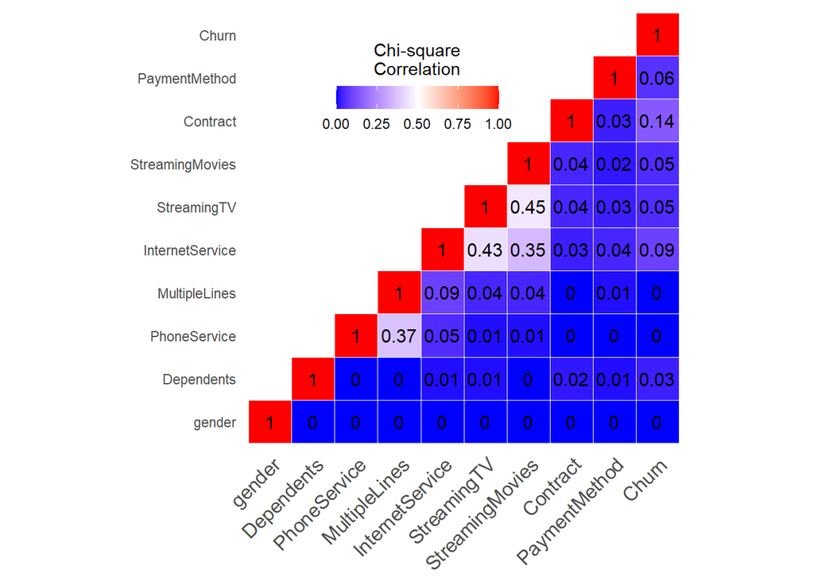

```r
library(reshape2)
library(ggplot2)
# funkcija za odsijecanje gornjeg dijela matrice
get_upper_tri <- function(cormat){
 cormat[lower.tri(cormat)]<- NA
 return(cormat)
}
upper_tri <- get_upper_tri(razlika_matrica)
melted_cormat <- melt(upper_tri, na.rm = TRUE)

ggheatmap <- ggplot(data = melted_cormat, aes(Var2, Var1, fill = value))+
geom_tile(color = "white")+
scale_fill_gradient2(low = "blue", high = "red", mid = "white",
 midpoint = 0.5, limit = c(0,1), space = "Lab",
 name="Chi-square\nCorrelation") +
 theme_minimal()+
theme(axis.text.x = element_text(angle = 45, vjust = 1,
 size = 12, hjust = 1))+
coord_fixed()
ggheatmap +
geom_text(aes(Var2, Var1, label = value), color = "black", size = 4) +
theme(
 axis.title.x = element_blank(),
 axis.title.y = element_blank(),
 panel.grid.major = element_blank(),
 panel.border = element_blank(),
 panel.background = element_blank(),
 axis.ticks = element_blank(),
 legend.justification = c(1, 0),
 legend.position = c(0.6, 0.7),
 legend.direction = "horizontal")+
 guides(fill = guide_colorbar(barwidth = 7, barheight = 1,
 title.position = "top", title.hjust = 0.5))
```

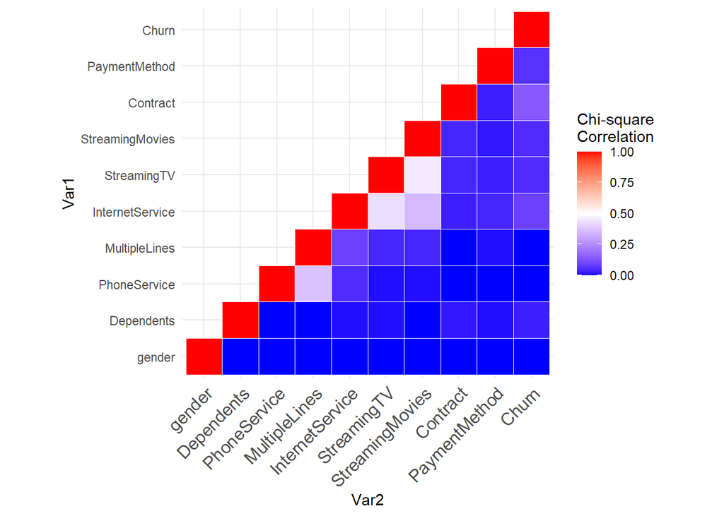

```r
 ggheatmap
```

```r
podaci <- subset(podaci, select = -c(MultipleLines, StreamingMovies, InternetService, TotalCharges))
```

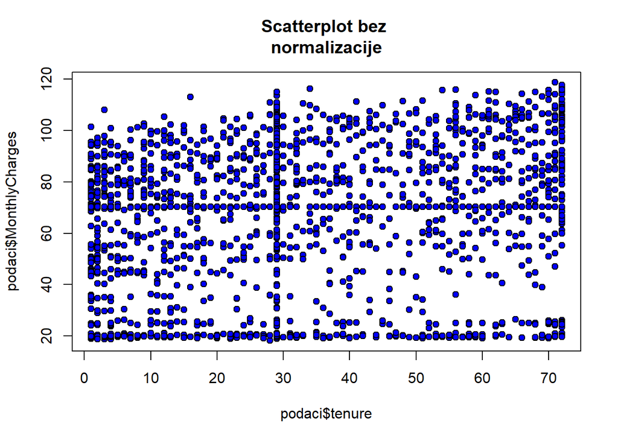

```r
#Normalizacija podataka

#MIn-max normalizacija
podaci_bez_normalizacije <- podaci
plot(podaci$tenure, podaci$MonthlyCharges, main = "Scatterplot bez
normalizacije", bg = "blue", pch = 21)
```

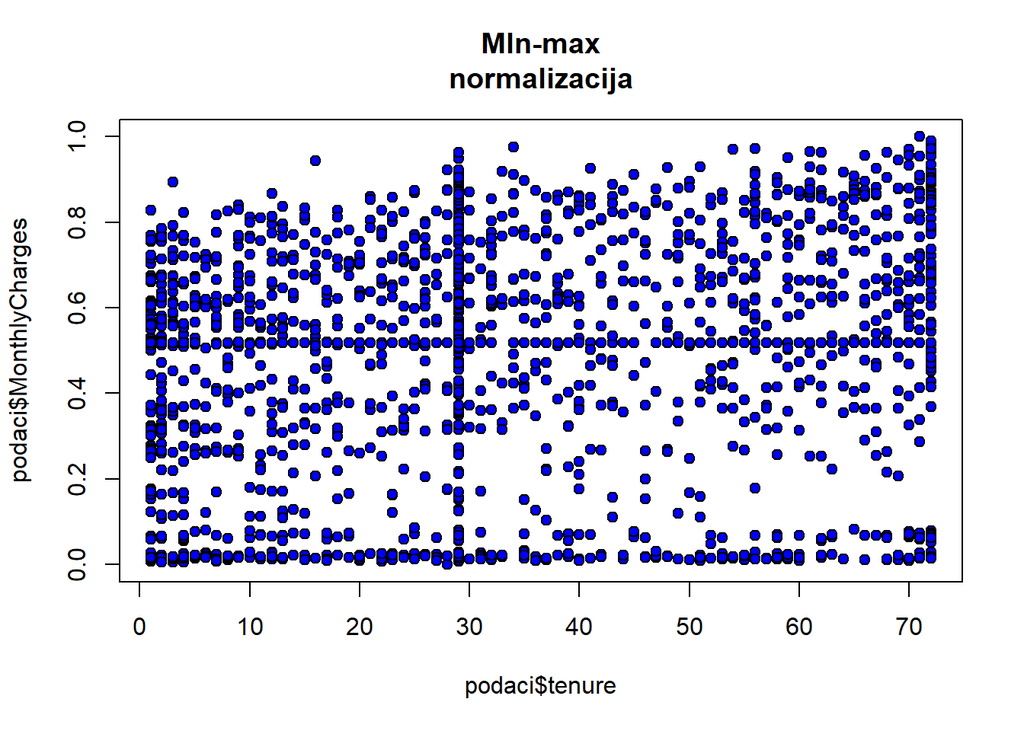

```r
max <- max(podaci$MonthlyCharges)
min <- min(podaci$MonthlyCharges)
podaci <- mutate(podaci, MonthlyCharges = (MonthlyCharges - min) / (max -
min))


plot(podaci$tenure, podaci$MonthlyCharges, main = "MIn-max
normalizacija", bg = "blue", pch = 21)
```

## **Zadatak 2** (Izgradnja modela klasifikacije)

### a)

Izgraditi sljedeće modele klasifikacije:

- drvo odlučivanja koje kao mjeru atributa selekcije koristi informacijsku dobit;
- drvo odlučivanja koje kao mjeru atributa selekcije koristi gini indeks;
- C5.0 model klasifikacije.

Izgradnju modela vršiti na sljedeći način: Prije izgradnje predikcijskih modela, na osnovu analize podataka potrebno je izvršiti sve potrebne korake preprocesiranja podataka (zadatak 1). Ovaj proces je potrebno dokumentovati na način da se prikažu poduzeti koraci, kao i da se daju objašnjenja i razlozi poduzimanja tih koraka. Zatim je potrebno izgraditi navedene klasifikacijske modele, dokumentovati i proces treniranja i testiranja modela, kao i rezultate evaluacije. Izvršiti čiščenje stabla za one modele za koje je to moguće. Ovaj korak se radi iterativno dok se ne dobiju rezultati za koje smatrate da su prihvatljivi.

Evaluacija istreniranih klasifikatora se vrši koristeći sljedeće metrike:

- konfuzijska matrica i mjere procjene koje se izvode na osnovu konfuzijske matrice (tačnost, osjetljivost, opoziv, F-mjera, itd.);
- ROC kriva;
- kappa statistika.

```r
draw_confusion_matrix <- function(cm)
{
 columns <- colnames(cm$table)
 rows <- rownames(cm$table)
 layout(matrix(c(1,1,2)))
 par(mar=c(2,2,2,2))
 plot(c(100, 345), c(300, 450), type = "n", xlab="", ylab="", xaxt='n',
yaxt='n')
 title('CONFUSION MATRIX', cex.main=2)
 rect(150, 430, 240, 370, col='#3F97D0')
 text(195, 435, columns[1], cex=1.2)
 rect(250, 430, 340, 370, col='#F7AD50')
 text(295, 435, columns[2], cex=1.2)
 text(125, 370, 'Predicted', cex=1.3, srt=90, font=2)
 text(245, 450, 'Actual', cex=1.3, font=2)
 rect(150, 305, 240, 365, col='#F7AD50')
 rect(250, 305, 340, 365, col='#3F97D0')
 text(140, 400, rows[1], cex=1.2, srt=90)
 text(140, 335, rows[2], cex=1.2, srt=90)
 res <- as.numeric(cm$table)
 text(195, 400, res[1], cex=1.6, font=2, col='white')
 text(195, 335, res[2], cex=1.6, font=2, col='white')
 text(295, 400, res[3], cex=1.6, font=2, col='white')
 text(295, 335, res[4], cex=1.6, font=2, col='white')
 plot(c(100, 0), c(100, 0), type = "n", xlab="", ylab="", main =
"DETAILS", xaxt='n', yaxt='n')
 text(10, 85, names(cm$byClass[1]), cex=1.2, font=2)
 text(10, 70, round(as.numeric(cm$byClass[1]), 3), cex=1.2)
 text(30, 85, names(cm$byClass[2]), cex=1.2, font=2)
 text(30, 70, round(as.numeric(cm$byClass[2]), 3), cex=1.2)
 text(50, 85, names(cm$byClass[5]), cex=1.2, font=2)
 text(50, 70, round(as.numeric(cm$byClass[5]), 3), cex=1.2)
 text(70, 85, names(cm$byClass[6]), cex=1.2, font=2)
 text(70, 70, round(as.numeric(cm$byClass[6]), 3), cex=1.2)
 text(90, 85, names(cm$byClass[7]), cex=1.2, font=2)
 text(90, 70, round(as.numeric(cm$byClass[7]), 3), cex=1.2)
 text(30, 35, names(cm$overall[1]), cex=1.5, font=2)
 text(30, 20, round(as.numeric(cm$overall[1]), 3), cex=1.4)
 text(70, 35, names(cm$overall[2]), cex=1.5, font=2)
 text(70, 20, round(as.numeric(cm$overall[2]), 3), cex=1.4)
}
```

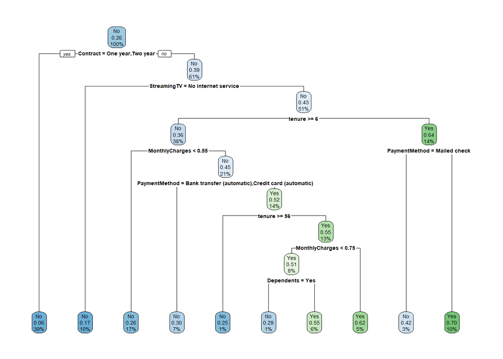

```r
#informacijska dobit


#faktorizacija kategorickih varijabli
podaci$gender <- factor(podaci$gender)
podaci$Dependents <- factor(podaci$Dependents)
podaci$PhoneService <- factor(podaci$PhoneService)
#podaci$MultipleLines <- factor(podaci$MultipleLines)
#podaci$InternetService <- factor(podaci$InternetService)
#podaci$StreamingMovies <- factor(podaci$StreamingMovies)
podaci$StreamingTV <- factor(podaci$StreamingTV)
podaci$Contract <- factor(podaci$Contract)
podaci$PaymentMethod <- factor(podaci$PaymentMethod)
podaci$Churn <- factor(podaci$Churn)

#podjela skupa na trening i testni skup
end <- length(podaci$Churn)
n <- as.integer(0.9 * end)
podaci_train <- podaci[1 : n, ]
podaci_test <- podaci[(n + 1) : end, ]

#kreiranje stabla odlucivanja
library(rpart)
tree_information <- rpart(formula = Churn ~ .,
 method = "class",
 data = podaci_train,
 parms = list(split = "information"))

#crtanje stabla odlucivanja
library(rpart.plot)
rpart.plot(tree_information)
```

```r
#kreiranje konfuzijske matrice
library(caret)
```

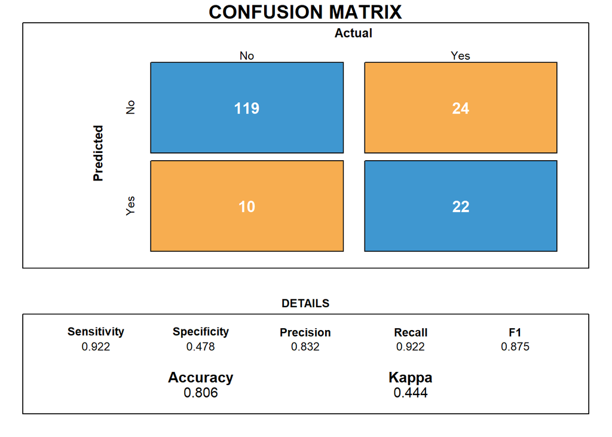

```r
prediction <- predict(tree_information, newdata = subset(podaci_test, select = -
c(Churn)))
prediction<-prediction[,1]
class_prediction <-ifelse(prediction > 0.50,"No","Yes")
class_prediction<-factor(class_prediction, levels=levels(podaci_test$Churn))

cm<-confusionMatrix(data=class_prediction, reference = podaci_test$Churn)
draw_confusion_matrix(cm)
```